# Variation in Penguin Body Mass Across Islands in the Palmer Archipelago

Tyler Rayman

2026-03-11

# Introduction

This study explores whether penguin body mass differs across islands using the Palmer Penguins dataset (Horst et al., 2020).

# Methods

## Data Source

Data were obtained from the `palmerpenguins` R package (Horst et al., 2020).  
The raw dataset was exported to CSV using `scripts/01_load_raw_penguins.R`.

Data cleaning was performed using `scripts/02_clean_penguins.R`, which: - Selected the variables `island` and `body_mass_g` - Removed rows containing missing values - Generated a processed dataset for analysis

## Statistical Analysis

All analyses were performed in R.

# Results

Mean body mass varied across islands (Figure 1).

|  | island | mean | sd | n |
| --- | --- | --- | --- | --- |
| Biscoe | Biscoe | 4716.02 | 782.86 | 167 |
| Dream | Dream | 3712.90 | 416.64 | 124 |
| Torgersen | Torgersen | 3706.37 | 445.11 | 51 |

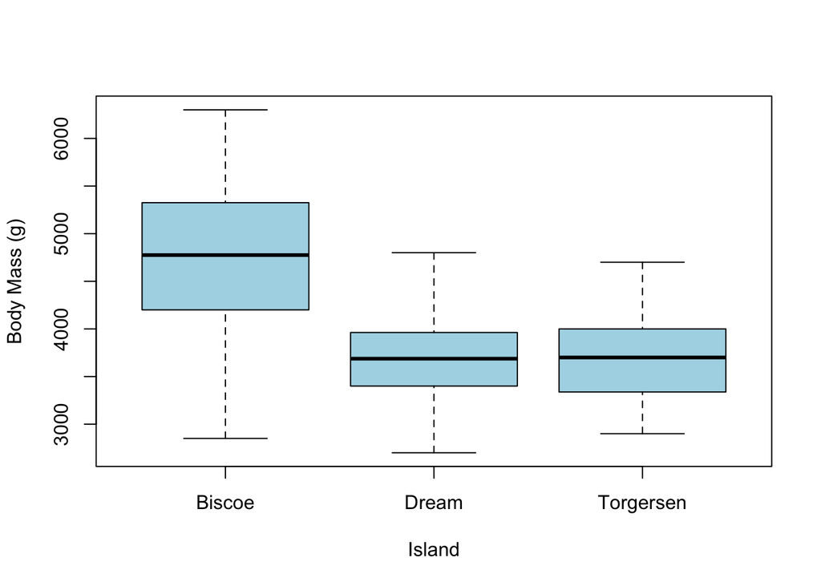

Figure 1: Distribution of penguin body mass across the three islands.

A one-way analysis of variance (ANOVA) revealed a significant effect of island on body mass (F(2, 339) = 110, p < 0.001). Post-hoc comparisons using Tukey’s Honestly Significant Difference (HSD) test indicated that penguins from Biscoe Island had significantly greater body mass than those from Dream and Torgersen islands (p < 0.001 for both comparisons), while body mass did not differ significantly between Dream and Torgersen islands (p = 0.998).

|  | Df | Sum Sq | Mean Sq | F value | Pr(>F) |
| --- | --- | --- | --- | --- | --- |
| island | 2 | 86314512 | 43157255.8 | 110.01 | 0 |
| Residuals | 339 | 132993186 | 392310.3 | NA | NA |

Mean penguin body mass varied across islands (Figure 1). A one-way analysis of variance (ANOVA) revealed a significant effect of island on body mass (F(2, 339) = 110, p < 0.001). Post-hoc comparisons using Tukey’s Honestly Significant Difference (HSD) test indicated that penguins from Biscoe Island had significantly greater body mass than those from Dream and Torgersen islands (p < 0.001 for both comparisons), while body mass did not differ significantly between Dream and Torgersen islands (p = 0.998).

# Discussion

Because this dataset is observational, results should not be interpreted as causal.

# Reproducibility

All data processing and analysis scripts are available in the `scripts` directory.